# Assignment 2 - Nobel Prizes

Kata Süle

14th December 2020

## Introduction

The aim of this web scraping project was to download the most amount of data from the website of the Nobel Prize. In order to make this happen I created a function which is able to retrieve the data in a clean and tabular format. Furthermore, by creating a few visualizations I also explored the resulting data frame.

## Scraping nobelprize.org

To scrape the website I used its [API](https://www.nobelprize.org/about/developer-zone-2/) and with the help of [this site](https://app.swaggerhub.com/apis/NobelMedia/NobelMasterData/2#/default/get_laureates) I was able to create a curl URL which I [transformed](https://curl.trillworks.com/#r) so that I could use it in R.

### Creating a function to scrape Nobel Prize laurates for one given category / or all categories in a given range of years

```r
get_nobel_data <- function( from, to, category = c( 'che', 'eco', 'lit', 'pea', 'phy', 'med' ) ) {

  df_full <- NULL

  # creating a list from the 'from' and 'to' parameters for the for loop
  years <- seq( from, to, 1)

  # saving the value of the 'category' parameter to a variable if the user gave one
  # if not the function retrieves all categories
  if ( length( category ) == 1 ){
    category <- category
  } else {
    category <- NULL
  }

  # downloading data for all the requested years
  for ( i in years ){
    require(httr)

    headers = c(
      `accept` = 'application/json'
    )

    params = list(
      `nobelPrizeYear` = as.character( i ),
      `nobelPrizeCategory` = category
    )

    # saving the results of the get request
    res <- httr::GET(url = 'http://api.nobelprize.org/2.0/laureates', httr::add_headers(.headers=headers), query = params)

    laurates <- fromJSON( content( res, 'text' ), flatten = T )

    # extracting the data frame on laurates
    laurates  <- laurates$laureates

    # in case the get request returns an empty list go to the next iteration
    if ( length( laurates ) == 0 ){
      next
    }

    # extracting the data frame on prizes
    prizes <- cbind( id = laurates$id, rbindlist( laurates$nobelPrizes, fill = T ) )

    # extracting the data frame on affiliations
    # this data is not always available for all laurates so the ids have to be linked
    # to this data frame as well where it is not null
    affiliations <- NULL
    for ( i in 1:nrow( prizes ) ){
      if ( is.null( prizes$affiliations[[ i ]] ) == FALSE ){
       # print( prizes$id[ i ] )
        a <- cbind( id = prizes$id[ i ], rbindlist( prizes$affiliations[ i ], fill = TRUE ) )
        affiliations <- rbind.fill( affiliations, a )
      }
    }

    # joining the laurates and the prizes data frames
    df <- full_join( laurates, prizes, by = 'id')

    # joining the df and the affiliations data frames if affiliations is not null
    if ( is.null( affiliations ) == FALSE ){
      df <- full_join( df, affiliations, by = 'id' )
    }

    # saving the joint data frame to df_full with a rowbind
    df_full <- rbind.fill( df_full, df )
  }

  # saving the column names of df_full
  df_full_colnames <- names( df_full )

  # filtering those column names that contain information in Swedish
  df_full_colnames <- setdiff( df_full_colnames,
                               df_full_colnames[ str_detect( df_full_colnames, ".se$" ) == TRUE ] )

  # filtering those column names that contain information in Norwegian
  df_full_colnames <- setdiff( df_full_colnames,
                               df_full_colnames[ str_detect( df_full_colnames, ".no$" ) == TRUE ] )

  possible_extra_columns <- c( 'nobelPrizes',  'givenName.en', 'familyName.en', 'birth.place.locationString.en', 'links.rel.x', 'links.href.x', 'links.action.x', 'links.types.x', 'sortOrder', 'affiliations', 'links.rel.y', 'links.href.y', 'links.action.y', 'links.types.y', 'residences', 'locationString.en',
'penName', 'death.place.locationString.en', 'acronym', 'founded.place.locationString.en', 'birthCountry.en', 'birthCountryNow.en', 'birthContinent.en', 'nativeName', 'founded.place.city.en', 'founded.place.country.en', 'founded.place.cityNow.en', 'founded.place.countryNow.en', 'founded.place.continent.en' )

  # filtering extra column names that are not useful for later analysis
  df_full_colnames <- setdiff( df_full_colnames, possible_extra_columns )

  # selecting the columns to keep
  df_full <- df_full %>% select( df_full_colnames )

  return( df_full )
}
```

### Testing the function

```r
# getting data for a range of years
between_years <- get_nobel_data( from = 1975, to = 1980 )
```

| id | gender | knownName.en | fullName.en | birth.date | birth.place.city.en | birth.place.country.en | birth.place.cityNow.en | birth.place.countryNow.en | birth.place.continent.en | death.date | death.place.city.en | death.place.country.en | death.place.cityNow.en | death.place.countryNow.en | death.place.continent.en | awardYear | portion | dateAwarded | prizeStatus | prizeAmount | prizeAmountAdjusted | category.en | categoryFullName.en | motivation.en | name.en | nameNow.en | city.en | country.en | cityNow.en | … |
| --- | --- | --- | --- | --- | --- | --- | --- | --- | --- | --- | --- | --- | --- | --- | --- | --- | --- | --- | --- | --- | --- | --- | --- | --- | --- | --- | --- | --- | --- | --- |
| 102 | male | Aage N. Bohr | Aage Niels Bohr | 1922-06-19 | Copenhagen | Denmark | Copenhagen | Denmark | Europe | 2009-09-08 | Copenhagen | Denmark | Copenhagen | Denmark | Europe | 1975 | 1/3 | 1975-10-17 | received | 630000 | 3404179 | Physics | The Nobel Prize in Physics | for the discovery of the connection between collective motion and particle motion in atomic nuclei and the development of the theory of the structure of the atomic nucleus based on this connection | Niels Bohr Institute | Niels Bohr Institute | Copenhagen | Denmark | Copenhagen | … |
| 534 | male | Andrei Sakharov | Andrei Dmitrievich Sakharov | 1921-05-21 | Moscow | Russia | Moscow | Russia | Europe | 1989-12-14 | Moscow | USSR | Moscow | Russia | Europe | 1975 | 1 | 1975-10-09 | received | 630000 | 3404179 | Peace | The Nobel Peace Prize | for his struggle for human rights in the Soviet Union, for disarmament and cooperation between all nations | NA | NA | NA | NA | NA | … |
| 103 | male | Ben R. Mottelson | Ben Roy Mottelson | 1926-07-09 | Chicago, IL | USA | Chicago, IL | USA | North America | NA | NA | NA | NA | NA | NA | 1975 | 1/3 | 1975-10-17 | received | 630000 | 3404179 | Physics | The Nobel Prize in Physics | for the discovery of the connection between collective motion and particle motion in atomic nuclei and the development of the theory of the structure of the atomic nucleus based on this connection | Nordita | Nordita | Copenhagen | Denmark | Copenhagen | … |
| 406 | male | David Baltimore | David Baltimore | 1938-03-07 | New York, NY | USA | New York, NY | USA | North America | NA | NA | NA | NA | NA | NA | 1975 | 1/3 | 1975-10-16 | received | 630000 | 3404179 | Physiology or Medicine | The Nobel Prize in Physiology or Medicine | for their discoveries concerning the interaction between tumour viruses and the genetic material of the cell | Massachusetts Institute of Technology (MIT) | Massachusetts Institute of Technology (MIT) | Cambridge, MA | USA | Cambridge, MA | … |
| 651 | male | Eugenio Montale | Eugenio Montale | 1896-10-12 | Genoa | Italy | Genoa | Italy | Europe | 1981-09-12 | Milan | Italy | Milan | Italy | Europe | 1975 | 1 | 1975-10-23 | received | 630000 | 3404179 | Literature | The Nobel Prize in Literature | for his distinctive poetry which, with great artistic sensitivity, has interpreted human values under the sign of an outlook on life with no illusions | NA | NA | NA | NA | NA | … |
| 408 | male | Howard M. Temin | Howard Martin Temin | 1934-12-10 | Philadelphia, PA | USA | Philadelphia, PA | USA | North America | 1994-02-09 | Madison, WI | USA | Madison, WI | USA | North America | 1975 | 1/3 | 1975-10-16 | received | 630000 | 3404179 | Physiology or Medicine | The Nobel Prize in Physiology or Medicine | for their discoveries concerning the interaction between tumour viruses and the genetic material of the cell | University of Wisconsin | University of Wisconsin | Madison, WI | USA | Madison, WI | … |
| 104 | male | James Rainwater | Leo James Rainwater | 1917-12-09 | Council, ID | USA | Council, ID | USA | North America | 1986-03-31 | Yonkers, NY | USA | Yonkers, NY | USA | North America | 1975 | 1/3 | 1975-10-17 | received | 630000 | 3404179 | Physics | The Nobel Prize in Physics | for the discovery of the connection between collective motion and particle motion in atomic nuclei and the development of the theory of the structure of the atomic nucleus based on this connection | Columbia University | Columbia University | New York, NY | USA | New York, NY | … |
| 247 | male | John Cornforth | John Warcup Cornforth | 1917-09-07 | Sydney | Australia | Sydney | Australia | Oceania | 2013-12-08 | NA | NA | NA | NA | NA | 1975 | 1/2 | 1975-10-17 | received | 630000 | 3404179 | Chemistry | The Nobel Prize in Chemistry | for his work on the stereochemistry of enzyme-catalyzed reactions | University of Sussex | University of Sussex | Brighton | United Kingdom | Brighton | … |
| 686 | male | Leonid Vitaliyevich Kantorovich | Leonid Vitaliyevich Kantorovich | 1912-01-19 | St. Petersburg | Russian Empire | St. Petersburg | Russia | Europe | 1986-04-07 | Moscow | USSR | Moscow | Russia | Europe | 1975 | 1/2 | 1975-10-14 | received | 630000 | 3404179 | Economic Sciences | The Sveriges Riksbank Prize in Economic Sciences in Memory of Alfred Nobel | for their contributions to the theory of optimum allocation of resources | Academy of Sciences | Academy of Sciences | Moscow | USSR | Moscow | … |
| 407 | male | Renato Dulbecco | Renato Dulbecco | 1914-02-22 | Catanzaro | Italy | Catanzaro | Italy | Europe | 2012-02-19 | La Jolla, CA | USA | La Jolla, CA | USA | North America | 1975 | 1/3 | 1975-10-16 | received | 630000 | 3404179 | Physiology or Medicine | The Nobel Prize in Physiology or Medicine | for their discoveries concerning the interaction between tumour viruses and the genetic material of the cell | Imperial Cancer Research Fund Laboratory | Imperial Cancer Research Fund Laboratory | London | United Kingdom | London | … |

[output cut: 58 more lines]

```r
# getting data for a given category in a range of years
years_and_cat <- get_nobel_data( from = 1980, to = 1985, category = 'lit' )
```

| id | gender | knownName.en | fullName.en | birth.date | birth.place.city.en | birth.place.country.en | birth.place.cityNow.en | birth.place.countryNow.en | birth.place.continent.en | death.date | death.place.city.en | death.place.country.en | death.place.cityNow.en | death.place.countryNow.en | death.place.continent.en | awardYear | portion | prizeStatus | prizeAmount | prizeAmountAdjusted | category.en | categoryFullName.en | motivation.en |
| --- | --- | --- | --- | --- | --- | --- | --- | --- | --- | --- | --- | --- | --- | --- | --- | --- | --- | --- | --- | --- | --- | --- | --- |
| 657 | male | Czeslaw Milosz | Czeslaw Milosz | 1911-06-30 | Śeteniai | Russian Empire | Śeteniai | Lithuania | Europe | 2004-08-14 | Kraków | Poland | Kraków | Poland | Europe | 1980 | 1 | received | 880000 | 2889667 | Literature | The Nobel Prize in Literature | who with uncompromising clear-sightedness voices man's exposed condition in a world of severe conflicts |
| 658 | male | Elias Canetti | Elias Canetti | 1905-07-25 | Ruse | Bulgaria | Ruse | Bulgaria | Europe | 1994-08-14 | Zurich | Switzerland | Zurich | Switzerland | Europe | 1981 | 1 | received | 1000000 | 2929688 | Literature | The Nobel Prize in Literature | for writings marked by a broad outlook, a wealth of ideas and artistic power |
| 659 | male | Gabriel García Márquez | Gabriel García Márquez | 1927-03-06 | Aracataca | Colombia | Aracataca | Colombia | South America | 2014-04-17 | Mexico City | Mexico | Mexico City | Mexico | North America | 1982 | 1 | received | 1150000 | 3102518 | Literature | The Nobel Prize in Literature | for his novels and short stories, in which the fantastic and the realistic are combined in a richly composed world of imagination, reflecting a continent's life and conflicts |
| 660 | male | William Golding | William Golding | 1911-09-19 | St. Columb Minor | United Kingdom | St. Columb Minor | United Kingdom | Europe | 1993-06-19 | Perranarworthal | United Kingdom | Perranarworthal | United Kingdom | Europe | 1983 | 1 | received | 1500000 | 3715324 | Literature | The Nobel Prize in Literature | for his novels which, with the perspicuity of realistic narrative art and the diversity and universality of myth, illuminate the human condition in the world of today |
| 661 | male | Jaroslav Seifert | Jaroslav Seifert | 1901-09-23 | Prague | Austria-Hungary | Prague | Czech Republic | Europe | 1986-01-10 | Prague | Czechoslovakia | Prague | Czech Republic | Europe | 1984 | 1 | received | 1650000 | 3782090 | Literature | The Nobel Prize in Literature | for his poetry which endowed with freshness, sensuality and rich inventiveness provides a liberating image of the indomitable spirit and versatility of man |
| 662 | male | Claude Simon | Claude Simon | 1913-10-10 | Tananarive | Madagascar | Antananarivo | Madagascar | Africa | 2005-07-06 | Paris | France | Paris | France | Europe | 1985 | 1 | received | 1800000 | 3843964 | Literature | The Nobel Prize in Literature | who in his novel combines the poet's and the painter's creativeness with a deepened awareness of time in the depiction of the human condition |

```r
# getting data for a given category in a range of years
nobel_2020 <- get_nobel_data( 2010, 2010 )
```

| id | gender | knownName.en | fullName.en | birth.date | birth.place.city.en | birth.place.country.en | birth.place.cityNow.en | birth.place.countryNow.en | birth.place.continent.en | death.date | death.place.city.en | death.place.country.en | death.place.cityNow.en | death.place.countryNow.en | death.place.continent.en | awardYear | portion | dateAwarded | prizeStatus | prizeAmount | prizeAmountAdjusted | category.en | categoryFullName.en | motivation.en | name.en | nameNow.en | city.en | country.en | cityNow.en | … |
| --- | --- | --- | --- | --- | --- | --- | --- | --- | --- | --- | --- | --- | --- | --- | --- | --- | --- | --- | --- | --- | --- | --- | --- | --- | --- | --- | --- | --- | --- | --- |
| 853 | male | Akira Suzuki | Akira Suzuki | 1930-09-12 | Mukawa | Japan | Mukawa | Japan | Asia | NA | NA | NA | NA | NA | NA | 2010 | 1/3 | 2010-10-06 | received | 10000000 | 10819388 | Chemistry | The Nobel Prize in Chemistry | for palladium-catalyzed cross couplings in organic synthesis | Hokkaido University | Hokkaido University | Sapporo | Japan | Sapporo | … |
| 849 | male | Andre Geim | Andre Geim | 1958-10-21 | Sochi | Russia | Sochi | Russia | Europe | NA | NA | NA | NA | NA | NA | 2010 | 1/2 | 2010-10-05 | received | 10000000 | 10819388 | Physics | The Nobel Prize in Physics | for groundbreaking experiments regarding the two-dimensional material graphene | University of Manchester | University of Manchester | Manchester | United Kingdom | Manchester | … |
| 858 | male | Christopher A. Pissarides | Christopher A. Pissarides | 1948-02-20 | Nicosia | Cyprus | Nicosia | Cyprus | Europe | NA | NA | NA | NA | NA | NA | 2010 | 1/3 | 2010-10-11 | received | 10000000 | 10819388 | Economic Sciences | The Sveriges Riksbank Prize in Economic Sciences in Memory of Alfred Nobel | for their analysis of markets with search frictions | London School of Economics and Political Science | London School of Economics and Political Science | London | United Kingdom | London | … |
| 857 | male | Dale T. Mortensen | Dale T. Mortensen | 1939-02-02 | Enterprise, OR | USA | Enterprise, OR | USA | North America | 2014-01-09 | Wilmette, IL | USA | Wilmette, IL | USA | North America | 2010 | 1/3 | 2010-10-11 | received | 10000000 | 10819388 | Economic Sciences | The Sveriges Riksbank Prize in Economic Sciences in Memory of Alfred Nobel | for their analysis of markets with search frictions | Northwestern University | Northwestern University | Evanston, IL | USA | Evanston, IL | … |
| 857 | male | Dale T. Mortensen | Dale T. Mortensen | 1939-02-02 | Enterprise, OR | USA | Enterprise, OR | USA | North America | 2014-01-09 | Wilmette, IL | USA | Wilmette, IL | USA | North America | 2010 | 1/3 | 2010-10-11 | received | 10000000 | 10819388 | Economic Sciences | The Sveriges Riksbank Prize in Economic Sciences in Memory of Alfred Nobel | for their analysis of markets with search frictions | Aarhus University | Aarhus University | Aarhus | Denmark | Aarhus | … |
| 852 | male | Ei-ichi Negishi | Ei-ichi Negishi | 1935-07-14 | Changchun | China | Changchun | China | Asia | NA | NA | NA | NA | NA | NA | 2010 | 1/3 | 2010-10-06 | received | 10000000 | 10819388 | Chemistry | The Nobel Prize in Chemistry | for palladium-catalyzed cross couplings in organic synthesis | Purdue University | Purdue University | West Lafayette, IN | USA | West Lafayette, IN | … |
| 850 | male | Konstantin Novoselov | Konstantin Novoselov | 1974-08-23 | Nizhny Tagil | Russia | Nizhny Tagil | Russia | Europe | NA | NA | NA | NA | NA | NA | 2010 | 1/2 | 2010-10-05 | received | 10000000 | 10819388 | Physics | The Nobel Prize in Physics | for groundbreaking experiments regarding the two-dimensional material graphene | University of Manchester | University of Manchester | Manchester | United Kingdom | Manchester | … |
| 855 | male | Liu Xiaobo | Liu Xiaobo | 1955-12-28 | Changchun | China | Changchun | China | Asia | 2017-07-13 | Shenyang | China | Shenyang | China | Asia | 2010 | 1 | 2010-10-08 | received | 10000000 | 10819388 | Peace | The Nobel Peace Prize | for his long and non-violent struggle for fundamental human rights in China | NA | NA | NA | NA | NA | … |
| 854 | male | Mario Vargas Llosa | Mario Vargas Llosa | 1936-03-28 | Arequipa | Peru | Arequipa | Peru | South America | NA | NA | NA | NA | NA | NA | 2010 | 1 | 2010-10-07 | received | 10000000 | 10819388 | Literature | The Nobel Prize in Literature | for his cartography of structures of power and his trenchant images of the individual's resistance, revolt, and defeat | NA | NA | NA | NA | NA | … |
| 856 | male | Peter A. Diamond | Peter A. Diamond | 1940-04-29 | New York, NY | USA | New York, NY | USA | North America | NA | NA | NA | NA | NA | NA | 2010 | 1/3 | 2010-10-11 | received | 10000000 | 10819388 | Economic Sciences | The Sveriges Riksbank Prize in Economic Sciences in Memory of Alfred Nobel | for their analysis of markets with search frictions | Massachusetts Institute of Technology (MIT) | Massachusetts Institute of Technology (MIT) | Cambridge, MA | USA | Cambridge, MA | … |

[output cut: 2 more lines]

## Exploratory Data Analysis

First I scraped the data for all the years by using the get_nobel_data function then I created three plots.

```r
# scrape the data for all the years
df_eda <- get_nobel_data( from = 1901, to = 2020 )
```

### 1. Exploring gender differences

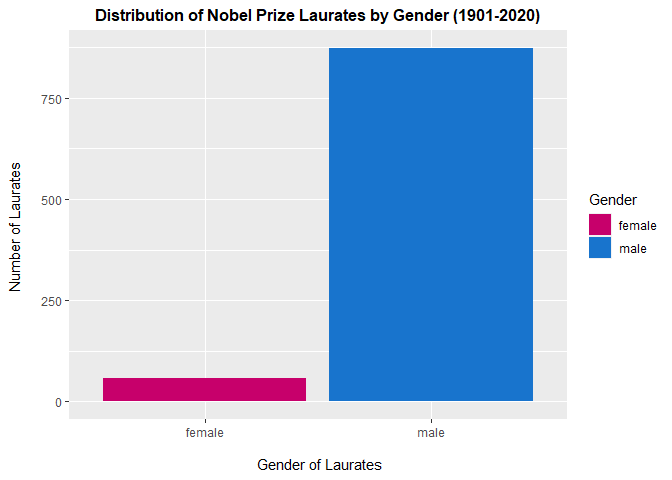

By looking at this plot it is easy to tell that the great majority of Nobel Prize Laurates are men. This is probably due to the fact that women were not allowed to pursue academic careers for a very long time.

### 2. Exploring differences between continents

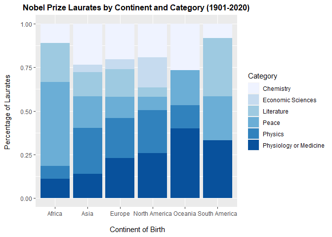

Based on this chart we can conclude that there are three continents - Asia, Europe and North-America - that were birth places of Laurates in all the six categories. It is interesting to mention that Economic Sciences Laurates were all born on the previously mentioned three continents.

### 3. Exploring differences between prizes

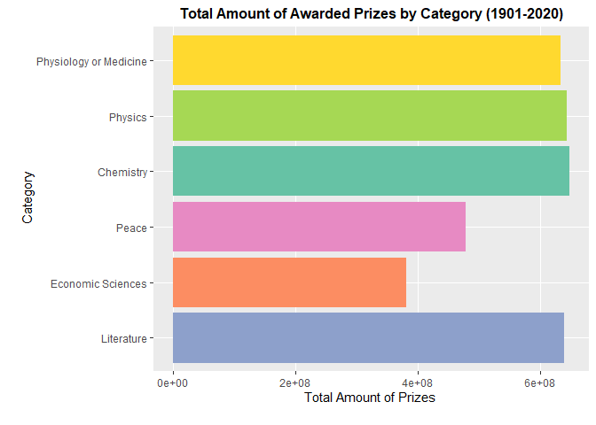

Based on this chart we can say that the highest amounts were awarded to the category of Chemistry, closely followed by Physics and Literature. The least amounts were awarded to the Economic Sciences category, however, the reason for this is probably that the category was created only in 1969.

## Summary

To conclude, by using the API of the Nobel Prize website and creating a function in R I was able to scrape data on Nobel Prize Laurates and store this data in a tabular format. The visualizations helped to discover a few interesting features of the data and since the resulting data frame contains a lot more variables it can be used for further analysis as well.